**FIFA Players Analytics**

# Introduction

In this project, we’ll explore the dynamics and important aspects of the FIFA World Cup, focusing on player potential, market values, and the connection between a player’s preferred foot and wages. By using detailed player data, our goal is to find valuable insights to help clubs improve their talent acquisition and management strategies. Our main focus will be answering these business questions:

**Question 1:** Predict the potential of the players to identify emerging talents using regularization methods.

**Question 2:** Predict a player’s market value based on key contributing factors using multiple linear regression.

**Question 3:** Predict whether the player should be classified as a high-wage player or a low-wage player using logistic regression.

**Question 4:** Test whether there is a significant difference in overall ratings between players from Europe and South America.

A Model predicting a player’s value can aid clubs in making informed decisions regarding transfers, negotiations, and financial investments in players.Similarly, A model predicting the potential of the players can help clubs in identifying and nurturing emerging talents can enhance a club’s long-term competitiveness and sustainability.Also, Understanding regional disparities in player ratings can inform scouting strategies and talent recruitment efforts across different continents.We will be answering the above questions by building models and carrying out hypothesis testings in R. Before we start building models and conducting hypothesis testing to answer these questions, we will carry out Exploratory Data Analysis in this part of the project.

# Exploratory Data Analysis

Exploratory Data Analysis (EDA) involves asking questions about your data and forming hypotheses based on what you learn.*(Nishida,2018)* Its goal is to explore data before making assumptions. EDA can help spot mistakes, understand patterns, find out liers, and discover relationships among variables *(Chaudhary,2023)*. Let’s dive deep into the data set and do the exploratory data analysis.

## Loading the data set:

```r
fifa_df <- read_csv("outputplayers20.csv")
summary(fifa_df)
str(fifa_df)
```

**About the Data set:** The dataset was obtained from Sports Statistics website and contains information about 18,483 FIFA players in year 2020 and encompasses approximately 110 attributes. It includes essential details such as player position, overall rating, market value, weekly wage, date of birth, physical traits (height, weight, body type), club affiliation, league, and nationality. Additionally, the dataset provides insights into preferred and weak foot, various skills like pace, shooting, and passing, as well as performance metrics such as attacking crossing and heading accuracy. Attributes related to player power, including shot power, power jumping, and power stamina, are also available. Moreover, the data set outlines player positions in different formations, such as ls, st, rs, lw, etc., along with other performance metrics.

```r
na_summary <- colSums(is.na(fifa_df))
na_summary_filtered <- na_summary[na_summary > 0]
table_1<- knitr::kable(na_summary_filtered, align = "c", caption = "Table 1: Columns with Null Values") %>%
    kable_classic(full_width = FALSE)
table_1
```

Table 1: Columns with Null Values

|  | x |
| --- | --- |
| value_eur | 250 |
| wage_eur | 240 |
| club_team_id | 240 |
| club_name | 240 |
| league_name | 240 |
| league_level | 625 |
| club_position | 240 |
| club_joined | 1288 |
| club_contract_valid_until | 240 |
| release_clause_eur | 1298 |
| pace | 2061 |
| shooting | 2061 |
| passing | 2061 |
| dribbling | 2061 |
| defending | 2061 |
| physic | 2061 |

## Data Cleaning

```r
columns_to_drop <- c(
  "player_url", "long_name", "dob", "club_jersey_number",
  "club_loaned_from", "nation_team_id", "nation_position",
  "nation_jersey_number", "work_rate", "real_face",
  "player_tags", "goalkeeping_speed", "player_face_url",
  "club_logo_url","player_traits", "club_flag_url", "nation_logo_url", "nation_flag_url"
)

fifa_df <- fifa_df[, !(names(fifa_df) %in% columns_to_drop)]
```

Columns with many null values were removed along with the columns that are not useful in the analysis of the project like columns containing url links.Still few columns with null values remained, however all of them were not treated as per the need in the further analysis.

## Adding and Treating Columns:

It was observed that some of the columns like ‘Player Positions’ contained very important information but in textual form and had more than one positions mentioned. Information about player position can be helpful in predicting potential or market values. Hence creating separate columns for all the positions:

```r
# Separating Player Positions column
fifa_df <- fifa_df %>%
  mutate(General_Position = case_when(
    grepl("GK", player_positions) ~ "Goalkeeper",
    grepl("(CB|LB|RB)", player_positions) ~ "Defender",
    grepl("(CM|CAM|LM|RM)", player_positions) ~ "Midfielder",
    grepl("(RW|LW|ST|CF)", player_positions) ~ "Attacker",
    TRUE ~ "Other"
  ))
```

The above code categorizes player positions into broader categories (e.g., Goalkeeper, Defender) to simplify analysis. This was done to facilitate exploratory data analysis by providing a clearer overview of player roles and distributions within the data set.

```r
# Treating Club Joined column
fifa_df$club_joined <- substr(fifa_df$club_joined, 1, 4)
```

```r
fifa_df <- fifa_df %>%
  mutate(Footdummy = ifelse(preferred_foot == "Right", 1, 0))
```

Next task was to convert the preferred position column that has categorical variables into factors of 0 and 1 with 1 denoting ‘Right’ foot so that it can be used during modelling.

```r
# Adding Wage class column to solve the third business question
fifa_df$wageclass <- ifelse(fifa_df$wage_eur > 10000, 1, 0)
fifa_df$wageclass <- as.factor(fifa_df$wageclass)
```

Since, we will be predicting high wage and low wage players for our logistic regression model. A wage class column was created where players with weekly wage more than 10000 euros were assigned 1 and the other were assigned 0.

## Treating Null Values and Integer Columns:

The data set contains a lot of columns with integer values so converting those integers values in numeric values will be better for modelling.

```r
# Converting integer values into numeric values
convert_int_to_numeric <- function(x) {
  if(is.integer(x)) {
    as.numeric(x)
  } else {
    x
  }
}
# Applying the function to relevant columns
fifa_df <- fifa_df %>%
  mutate_if(is.integer, convert_int_to_numeric)
```

Further, checking descriptive statistics for numerical variables is important as it can given important information that can be sued while treating the null values.

```r
# Checking summary and treating null values
summary(fifa_df %>% select_if(is.numeric))

fifa_df_cleaned <- na.omit(fifa_df)

summary(fifa_df_cleaned)
```

It was observed that there were some null values present in some of the columns.These null values were omitted as they were very few in numbers as compared to total observations and would not really affect the modelling.

## Exploratory Analysis using Graphs and Visulaisations:

In order to build predictive regression models to solve our business questions, one of the most important to check in EDA is checking the correlation matrix to obtain information about which variables are highly correlated to the response variable and is there any correlation between the independent variables or predictors.

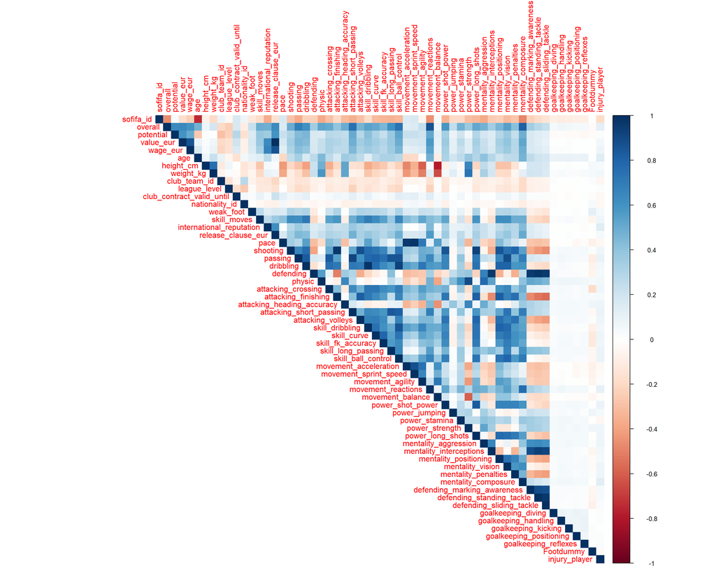

Fig.1:Correlation Matirx with All Numerical Variables

```r
# Correlation Matrix
cor_matrix_cleaned <- cor(fifa_df_cleaned %>% select_if(is.numeric))
corrplot(cor_matrix_cleaned, method = "color", type = "upper")
```

**Observations:**It can be observed that overall rating, potentil, market value variables had high correlation with some of the variables like market value variable had comparatively strong correlation with release clause error, mentality composure, international reputation, attacking features, etc.However, as it can be also be seen in figure 1, there are a few variables that are highly correlated to each other showing the signs of multicollinearity. Multicollinearity arises when independent variables in a regression model exhibit high correlation with each other. In such cases, alterations in one variable can induce corresponding changes in another, leading to substantial fluctuations in the model results *(Wu,2020)*. It will important to check for multicollinearity while select feature for the models.

```r
# Finding highly correlated variables
cutoff <- 0.9
highly_correlated_cols <- which(
  upper.tri(cor_matrix_cleaned, diag = TRUE) &   # Exclude lower triangle and diagonal
  abs(cor_matrix_cleaned) > cutoff,               # Apply correlation cutoff
  arr.ind = TRUE
)

# Excluding pairs where both columns are the same
valid_correlation_pairs <- highly_correlated_cols[highly_correlated_cols[, 1] != highly_correlated_cols[, 2], ]

# Get the names of highly correlated columns
highly_correlated_cols_names <- colnames(cor_matrix_cleaned)

# Pairs of higly correlated variables
for (pair in 1:nrow(valid_correlation_pairs)) {
  col1_name <- highly_correlated_cols_names[valid_correlation_pairs[pair, 1]]
  col2_name <- highly_correlated_cols_names[valid_correlation_pairs[pair, 2]]
  cat(sprintf("Pair %d: %s, %s\n", pair, col1_name, col2_name))
}
```

```
## Pair 1: value_eur, release_clause_eur
## Pair 2: shooting, attacking_finishing
## Pair 3: passing, attacking_short_passing
## Pair 4: dribbling, skill_dribbling
## Pair 5: dribbling, skill_ball_control
## Pair 6: pace, movement_acceleration
## Pair 7: pace, movement_sprint_speed
## Pair 8: shooting, power_long_shots
## Pair 9: defending, mentality_interceptions
## Pair 10: defending, defending_marking_awareness
## Pair 11: defending, defending_standing_tackle
## Pair 12: mentality_interceptions, defending_standing_tackle
## Pair 13: defending, defending_sliding_tackle
## Pair 14: mentality_interceptions, defending_sliding_tackle
## Pair 15: defending_standing_tackle, defending_sliding_tackle
```

**Observations:** It can be observed that some of the variables are highly collinear with each other. That means they depend on each other. Son in order to avoid, multicollinearity in our model, we should avoid selecting dependent features simultaneously for predicting market values. For example, we should avoid using shooting and attacking finishing in the same model.

## Checking Variables that are highly correlated to Market Value

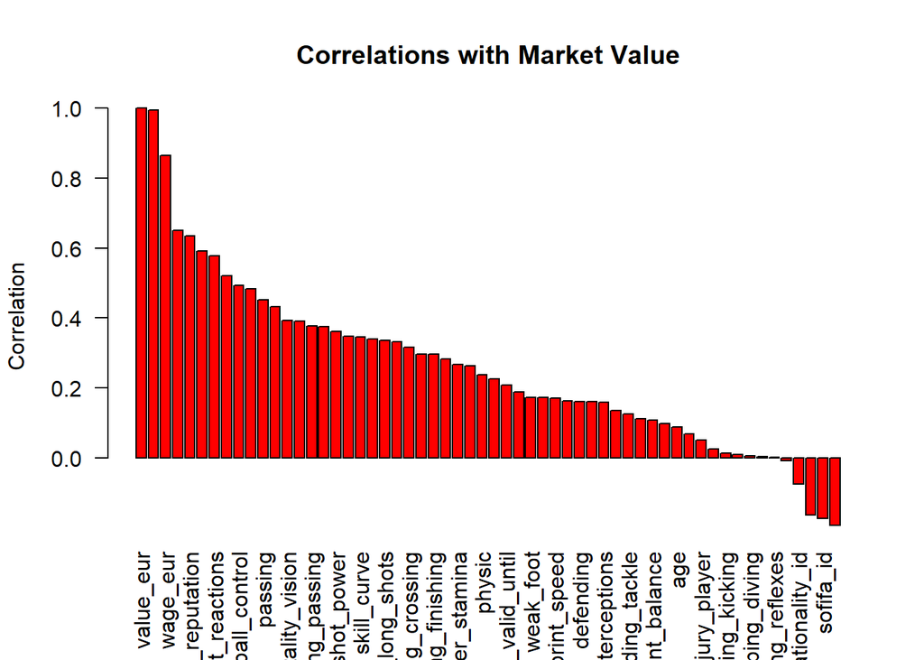

Fig.2:Correlation

```r
cor_with_value_eur <- cor_matrix_cleaned[,"value_eur"]
sorted_correlations <- sort(cor_with_value_eur, decreasing = TRUE)

barplot(sorted_correlations, col = "red", main = "Correlations with Market Value",
        ylab = "Correlation", names.arg = names(sorted_correlations), las = 2)
```

**Observations:** It can be observed from figure 2 that variables like weekly wage, international reputation, movement reactions etc show high correlation with market value. We can select only variables that show more than 0.5 collinearity with market value for our model.

## Checking For Outliers

An outlier represents a data point within a dataset that deviates notably from other observations. These instances are particularly noteworthy as they possess the potential to exert a substantial impact on the least squares line. Therefore, it is crucial to assess and address out liers diligently. *(Wijaya,2020)*

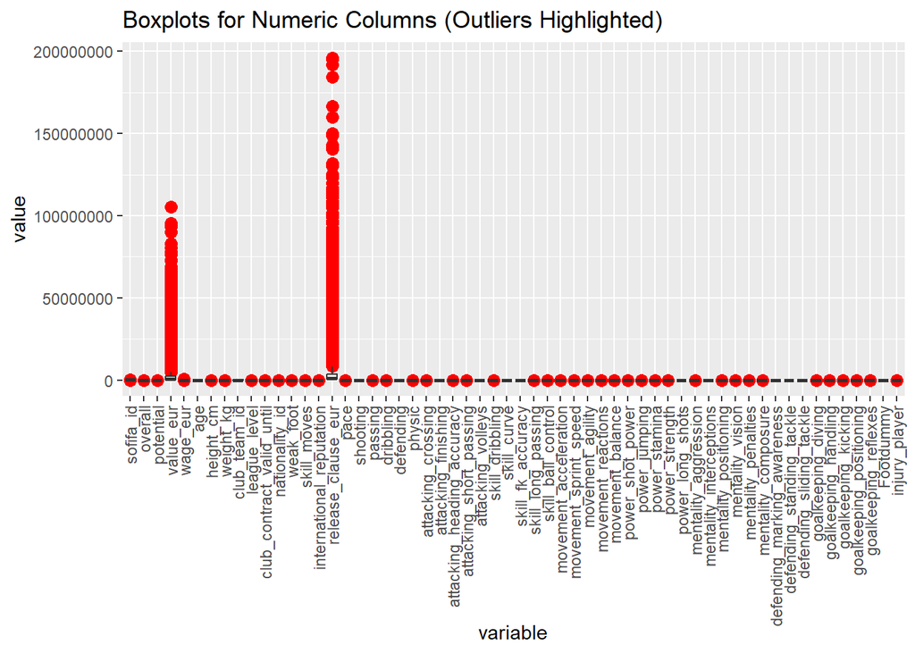

Fig.3:Outliers

```r
# Creating function to plot outliers
plot_outliers <- function(data) {
  numeric_columns <- sapply(data, is.numeric)
  numeric_data <- data[, numeric_columns, drop = FALSE]

  # Melt the data for plotting
  melted_data <- reshape2::melt(numeric_data)

  # Create boxplots with rotated x-axis labels and red outliers
  ggplot(melted_data, aes(x = variable, y = value)) +
    geom_boxplot(outlier.colour = "red", outlier.shape = 16, outlier.size = 3) +
    labs(title = "Boxplots for Numeric Columns (Outliers Highlighted)") +
    theme(axis.text.x = element_text(angle = 90, vjust = 0.5, hjust = 1))
}

# Plot outliers with rotated x-axis labels and red color
plot_outliers(fifa_df_cleaned)
```

**Observations**:From figure 3, tt can be observed that there are quite a few outliers present in market value variable. We need to check if these outliers have influence on the model fit and can be removed if needed.We can ignore the outliers present in release clause for now as it need not be used during modelling due to multicollinearity as seen in one of the above tasks.

To explore that data set further in order to do built the logistic regression model to classify players with high wages, we can first convert the wages into two different factors and then see how these factors interact with different independent variables.

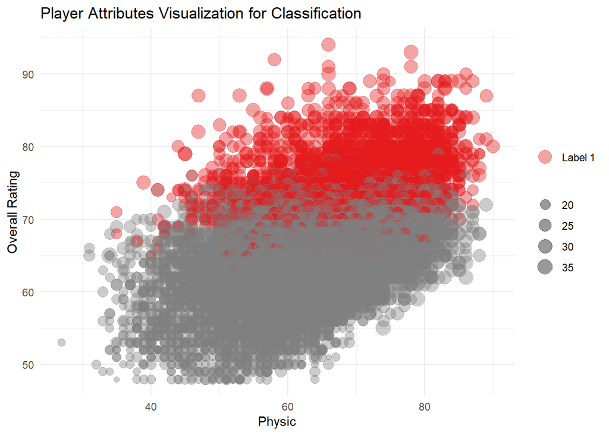

Fig.4:Player Attributes

```r
# Ploting
fifa_df_cleaned$wageclass <- as.factor(fifa_df_cleaned$wageclass)
fifa_df_plot <- na.omit(fifa_df_cleaned[, c("physic", "overall", "wageclass", "age")])

ggplot(fifa_df_plot, aes(x = physic, y = overall)) +
 geom_point(aes(color = wageclass, size = age), alpha = 0.4) +
 scale_color_manual(values = c("1" = "#E41A1C", "2" = "#377EB8"), labels = c("1" = "Label 1", "2" = "Label 2")) +
 scale_size(range = c(2, 6)) +
 theme_minimal() +
 theme(legend.position = "right", legend.title = element_blank()) +
 labs(
   title = "Player Attributes Visualization for Classification",
   x = "Physic",
   y = "Overall Rating",
   color = "Wageclass",
   size = "Age"
 ) +
 guides(color = guide_legend(override.aes = list(size = 5)))
```

To do further analysis about the regions of the players to solve our fourth business question, we will define European and South American Region

```r
# Defining regions
european_countries <- c("Portugal", "Belgium", "Slovenia", "Croatia", "Germany", "Netherlands", "Italy", "Spain", "Poland", "France", "England", "Denmark", "Bosnia and Herzegovina", "Slovakia", "Sweden", "Wales", "Hungary", "Switzerland", "Greece", "Austria", "Serbia", "Czech Republic", "Norway", "Iceland", "Finland", "Scotland", "Albania", "Kosovo", "Republic of Ireland", "Northern Ireland", "Romania", "Turkey", "Armenia", "Russia", "Montenegro", "Bulgaria", "Estonia", "Moldova", "Ukraine", "Georgia", "Lithuania", "Latvia", "Luxembourg", "Azerbaijan", "Kazakhstan", "Faroe Islands", "Liechtenstein", "Malta", "San Marino", "Vatican City")
south_american_countries <- c("Argentina", "Brazil", "Uruguay", "Chile", "Colombia", "Ecuador", "Paraguay", "Peru", "Venezuela", "Bolivia")
```

Now let’s create a variable showing the region of the player:

```r
fifa_df_cleaned$region <- ifelse(fifa_df_cleaned$nationality_name %in% european_countries, "Europe",
                            ifelse(fifa_df_cleaned$nationality_name %in% south_american_countries, "South America", "Other"))
```

Now we can check if there is any difference between the overall rating mean of Europian players and South American players.

```r
mean_overall_europe <- mean(fifa_df_cleaned$overall[fifa_df_cleaned$region == "Europe"], na.rm = TRUE)

mean_overall_south_america <- mean(fifa_df_cleaned$overall[fifa_df_cleaned$region == "South America"], na.rm = TRUE)

mean_overall_df <- data.frame(
  "Mean Overall Ratings for Europian Players" =mean_overall_europe ,
  "Mean Overall Ratings for South American Players" = mean_overall_south_america
)

table_2<-knitr::kable(mean_overall_df, align = "c",
                        caption = "Table 2: Mean Overall Ratings for Different Regions") %>%
    kable_classic(full_width = FALSE)
table_2
```

Table 2: Mean Overall Ratings for Different Regions

| Mean.Overall.Ratings.for.Europian.Players | Mean.Overall.Ratings.for.South.American.Players |
| --- | --- |
| 66.11993 | 68.56536 |

**Observation** : It can be observed that there is slight difference between the mean overall rating of European players and South American players. But is it statistically significant? That can be found using the hypothesis testing.

[figure not shown]

Fig.5:Overall Rating by Region

```r
ggplot(data = fifa_df_cleaned, aes(x = region, y = overall)) +
  geom_boxplot(fill = "coral4", color = "seagreen") +
  labs(title = "Overall Ratings by Region",
       x = "Region",
       y = "Overall Rating") +
  scale_x_discrete(labels = c("Europe", "South America", "Other"))
```

In order to carry out hypothetical testing, it is important to check if the distribution is following normal distribution or not. This can be checked using histogram.

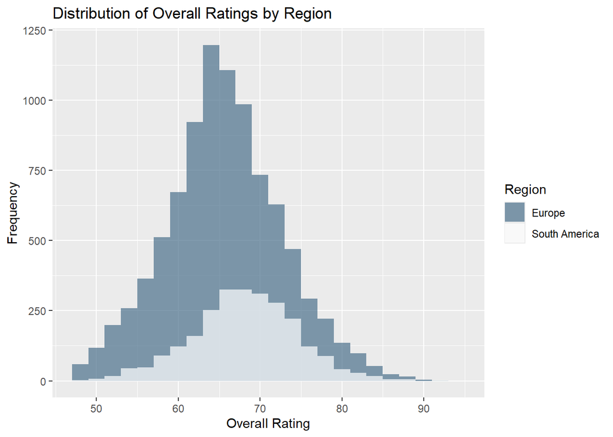

Fig.6:Distribution of Overall Ratings by Region

```r
# Histogram
fifa_df_plot<- fifa_df_cleaned %>%
                      filter(region %in% c('Europe', 'South America'))
ggplot(data = fifa_df_plot, aes(x = overall, fill = region)) +
  geom_histogram(binwidth = 2, alpha = 0.7, position = "identity") +
  labs(title = "Distribution of Overall Ratings by Region",
       x = "Overall Rating",
       y = "Frequency",
       fill = "Region") +
  scale_fill_manual(values = c("skyblue4", "white"))
```

# Data Anlysis:

## Question 1: Predict the potential of the players to identify emerging talents using regularization methods.

In this model, we aim to develop a predictive tool for assessing players’ overall potential. Factors such as physique, age, and performance across various levels will be considered. Before applying regularization techniques to construct the model, it is imperative to address variables showing significant collinearity or multicollinearity with other predictors.

Collinearity denotes the linear association among two or more predictors in a regression model, while multicollinearity arises when predictors are strongly correlated, hindering the estimation of individual predictor effects on the target variable *(Songara,2022)*.

During exploratory data analysis (EDA), variables demonstrating high collinearity or multicollinearity are identified through correlation matrices and variance inflation factor (VIF). Consequently, one variable from each pair is removed.

```r
fifa_df_BQ2 <- fifa_df_cleaned

# Iterate over each pair of highly correlated columns
for (pair in 1:nrow(valid_correlation_pairs)) {
  col1_index <- valid_correlation_pairs[pair, 1]
  col2_index <- valid_correlation_pairs[pair, 2]

  #Removing columns from the dataframe
  fifa_df_BQ2 <- fifa_df_BQ2[, -col2_index]
}
```

With 82 variables remaining, it becomes computationally burdensome to incorporate all of them into the model. Therefore, further reduction is necessary. Height and weight variables typically exhibit correlation, yet instead of discarding one of them outright, a more nuanced approach involves creating a new variable representing Body Mass Index (BMI) derived from height and weight. This new variable, capturing a combination of both height and weight, can then be integrated into the model, contributing to a more comprehensive understanding of the relationship between body composition and the target variable.

```r
fifa_df_BQ2$height_m <- fifa_df_BQ2$height_cm / 100
# Calculate BMI
fifa_df_BQ2$BMI <- fifa_df_BQ2$weight_kg / (fifa_df_BQ2$height_m)^2

fifa_df_BQ2 <- fifa_df_BQ2[, !names(fifa_df_BQ2) %in% c("height_cm", "weight_kg","height_m" )]
```

The data frame contains numerous non numeric variables so, selecting only numeric variables for prediction. We will be using only numeric columns to build regularization model.So, plotting the correlation matrix for numeric columns to remove higly correlated variables.

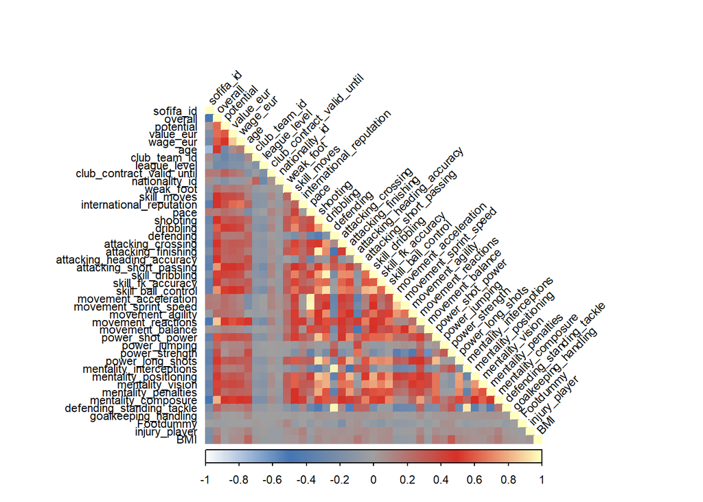

Fig.7:Correlation Matrix for Numeric Variables

```r
fifa_df_BQ2_num<- select_if(fifa_df_BQ2, is.numeric)

# Calculate the correlation matrix for numeric columns
corr_matrix_BQ2 <- cor(fifa_df_BQ2_num, use = "pairwise.complete.obs")

corrplot(corr_matrix_BQ2, method = "color", type = "lower",
         tl.col = "black", tl.srt = 45,
         tl.cex = 0.7, cl.cex = 0.7, number.cex = 0.7,
         col = colorRampPalette(c("#FFFFFF", "#4575b4", "#a0a0a0", "#d73027", "#ffffbf"))(200))
```

```r
#Finding columns with high collinearity
high_collinear_BQ2 <- findCorrelation(corr_matrix_BQ2, cutoff = 0.9)

#Removing highly collinear columns from the dataframe
fifa_df_BQ2_num <- fifa_df_BQ2_num[, -high_collinear_BQ2]
```

We will now be splitting the data set into train and test data set to build model.We split the dataset into training and testing sets to develop predictive models on the training data and evaluate their performance on unseen data, ensuring the model’s generalization and estimating its effectiveness in real-world scenarios *(Casati,2022)*. We will be splitting dataset into 80 and 20 ratio so that model is trained on 80% of the dataset and tested on the remaining 20% of the dataset.

```r
fifa_df_BQ2_num<- select_if(fifa_df_BQ2, is.numeric)

set.seed(354)
smpl_i<-createDataPartition(fifa_df_BQ2_num$potential, list = FALSE,p=0.8, times = 1)
fifa_BQ2_train<-fifa_df_BQ2_num[smpl_i,]
fifa_BQ2_test<-fifa_df_BQ2_num[-smpl_i,]

potential_i<- which(colnames(fifa_df_BQ2_num) == "potential")
# x values
fifa_BQ2_train_x<-model.matrix(potential~.,fifa_BQ2_train)[,-potential_i]
fifa_BQ2_test_x<-model.matrix(potential~.,fifa_BQ2_test)[,-potential_i]
#y values
fifa_BQ2_train_y<-fifa_BQ2_train$potential
fifa_BQ2_test_y<-fifa_BQ2_test$potential
```

To construct a predictive model for assessing overall potential, our initial approach involves implementing ridge regularization. This technique, by introducing a penalty term to the regression coefficients, helps mitigate multicollinearity and overfitting, thus enhancing model generalization and robustness. Subsequently, we will evaluate the predictive model’s performance by examining the Root Mean Squared Error (RMSE) values.

## Ridge Regularization Model:

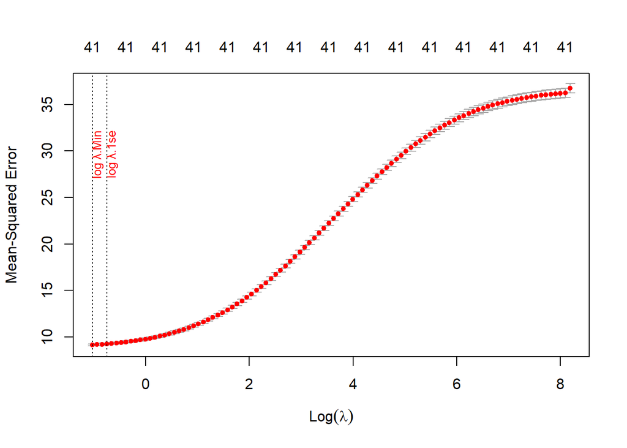

Fig.8:Ridge-Cross Validation Plot

```r
set.seed(354)
ridge_BQ2 <- cv.glmnet(fifa_BQ2_train_x, fifa_BQ2_train_y, alpha = 0, nfolds = 10)

Lambda_min_ridge_BQ2 <- ridge_BQ2$lambda.min
Lambda_1se_ridge_BQ2 <- ridge_BQ2$lambda.1se

# Plot the cross-validation results
plot(ridge_BQ2)
text(log(ridge_BQ2$lambda.min), max(ridge_BQ2$cvm)/1.2,
     labels ="log λ.Min",
     pos = 1,srt=90,cex=0.8, col = "red")

text(log(ridge_BQ2$lambda.1se), max(ridge_BQ2$cvm)/1.2,
     labels ="log λ.1se",
     pos = 1, col = "red",cex=0.8, srt=90)
```

It can be observed that the number of terms in Ridge model are 41 which is making the model complex. Also, the lambda values are quite close to each other. We can try to fit Lasso model as it will reduce the number of variables. But before moving forward, let’s check how the ridge model is performing.

```r
set.seed(354)

ridge_model_BQ2_1se <- glmnet(fifa_BQ2_train_x, fifa_BQ2_train_y, alpha = 0, lambda = Lambda_1se_ridge_BQ2)

# Coefficients for lambda 1se model
ridge_model_BQ2_1se_coef <- coef(ridge_model_BQ2_1se)

# Prediction on train data set
pred_train_ridge_BQ2_1se <- predict(ridge_model_BQ2_1se, newx = fifa_BQ2_train_x)
rmse_train_ridge_BQ2_1se <- sqrt(mean((fifa_BQ2_train_y - pred_train_ridge_BQ2_1se)^2))
```

In order to see the performance of the model, we will be plotting actual versus predicted overall potential values:

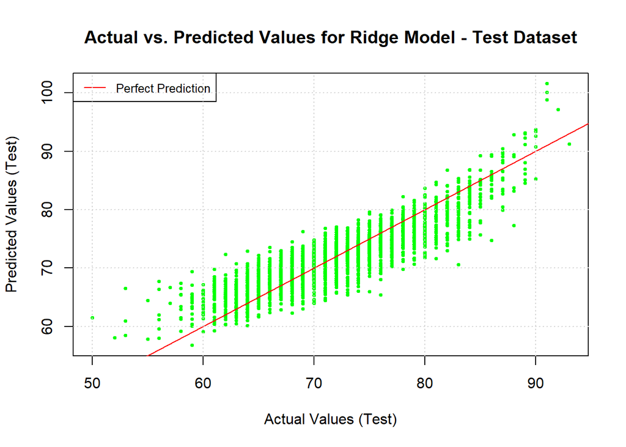

Fig.9:Actual Vs Predicted Values for Ridge Model

```r
pred_test_ridge_BQ2_1se <- predict(ridge_model_BQ2_1se, newx = fifa_BQ2_test_x)

plot(fifa_BQ2_test_y, pred_test_ridge_BQ2_1se,
     xlab = "Actual Values (Test)",
     ylab = "Predicted Values (Test)",
     main = "Actual vs. Predicted Values for Ridge Model - Test Dataset",
     pch = 20, # Change the point character to a solid circle
     col = "green", # Change the color of the points to green
     cex = 0.7) # Reduce the size of the points

# Add a diagonal line for reference
abline(0, 1, col = "red")

# Add a legend
legend("topleft", legend = "Perfect Prediction", col = "red", lty = 1, cex = 0.8)

# Add a grid
grid()
```

It can be observed that the predicted values are not very far from the actual values and also the distribution of predicted values is random which is a sign of a good model.

Let’s now evaluate the Ridge model using RMSE values. RMSE (Root Mean Squared Error) measures the average magnitude of the errors between predicted and actual values, providing a standardized assessment of prediction accuracy. We calculate the RMSE by taking the square root of the average squared differences between predicted and actual values. A lower RMSE indicates better predictive performance, reflecting the model’s ability to minimize prediction errors *(Moody,2019)*.

Let’s now check the RMSE values on the test data set:

```r
rmse_test_ridge_BQ2_1se <- sqrt(mean((fifa_BQ2_test_y - pred_test_ridge_BQ2_1se)^2))


##RMSE values for Ridge
ridge_BQ2_df <- data.frame(
  "RMSE for Train" = rmse_train_ridge_BQ2_1se,
  "RMSE for Test" = rmse_test_ridge_BQ2_1se
)

table_BQ2_1<-knitr::kable(ridge_BQ2_df, align = "c",
                        caption = "Table 3: RMSE Values for Ridge Regression") %>%
    kable_classic(full_width = FALSE)
table_BQ2_1
```

Table 3: RMSE Values for Ridge Regression

| RMSE.for.Train | RMSE.for.Test |
| --- | --- |
| 3.031345 | 3.01702 |

In our attempt with ridge regularization, we noticed that it didn’t effectively eliminate variables, and considering the model already comprises numerous variables, it tends to become overly complex. Now, we aim to explore Lasso regression as an alternative. Unlike ridge regression, Lasso regression has the capability to automatically eliminate less significant variables by shrinking their coefficients to zero. This feature makes Lasso regression a suitable choice for reducing the complexity of our model while retaining its predictive performance.

## Lasso Regularization:

Lasso regularization, also known as L1 regularization, is a technique used in regression analysis to penalize the absolute size of the coefficients. It adds a penalty term to the regression equation, encouraging the coefficients of less important features to be exactly zero, effectively performing feature selection and improving model interpretability. Lasso regularization helps prevent overfitting and can handle multicollinearity in the dataset *(Manwani,2021)*.

Let’s build Lasso model:

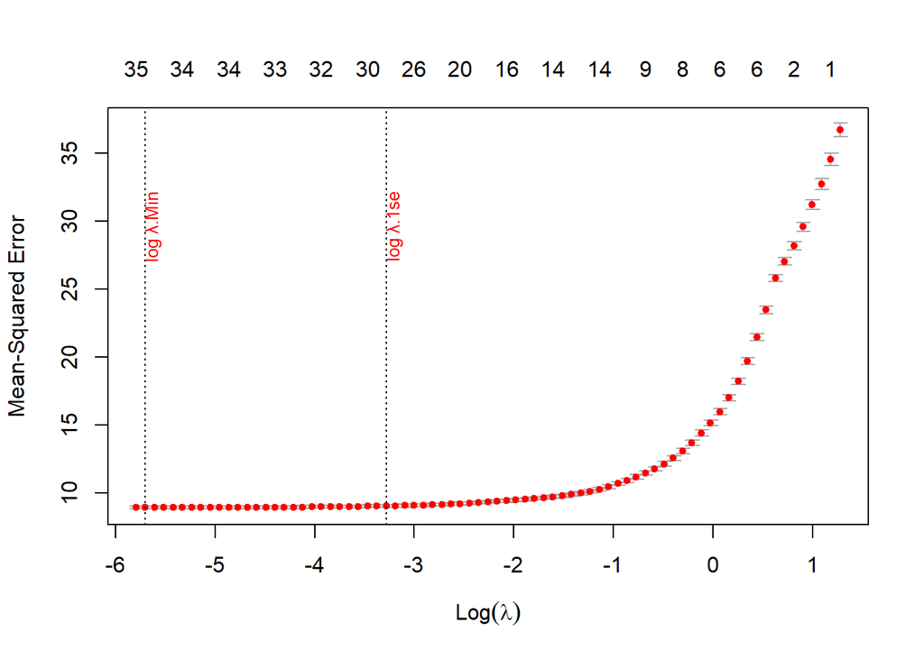

Fig.10:Lasso-Cross Validation Plot

```r
#Finding lambda values for Lasso
set.seed(354)
lasso_BQ2<-cv.glmnet(fifa_BQ2_train_x, fifa_BQ2_train_y,alpha=1, nfolds = 10)

Lambda_min_BQ2<-lasso_BQ2$lambda.min
Lambda_1se_BQ2<-lasso_BQ2$lambda.1se

plot(lasso_BQ2)
text(log(lasso_BQ2$lambda.min), max(lasso_BQ2$cvm)/1.2,
     labels ="log λ.Min",
     pos = 1,srt=90,cex=0.8, col = "red")

text(log(lasso_BQ2$lambda.1se), max(lasso_BQ2$cvm)/1.2,
     labels ="log λ.1se",
     pos = 1, col = "red",cex=0.8, srt=90)
```

It can be observed that the lambda.1se is a better choice as the mean-square root value is low and at the same time it has fewer number of variables as compared to lambda min:

```r
lam_las_df<-data.frame(
  "Lambda Min"=Lambda_min_BQ2,
  "Lambda 1se"=Lambda_1se_BQ2
)

table_4<-knitr::kable(lam_las_df, align = "c",digits=4, caption = "Table 4: Lambda Values for Lasso") %>%
    kable_classic(full_width = FALSE)
table_4
```

Table 4: Lambda Values for Lasso

| Lambda.Min | Lambda.1se |
| --- | --- |
| 0.0033 | 0.0376 |

Let’s now build Lasso model using lambda 1se on train dataset:

```r
#Lasso model on train data set
set.seed(354)

lasso_model_BQ2_1se <- glmnet(fifa_BQ2_train_x, fifa_BQ2_train_y, alpha = 1, lambda = Lambda_1se_BQ2)

#Coefficients for lambda 1se model
lasso_model_BQ2_1se_coef<-coef(lasso_model_BQ2_1se)

#Prediction on train data set
pred_train_BQ2_1se<-predict(lasso_model_BQ2_1se, newx =fifa_BQ2_train_x)
rmse_train_BQ2_1se<-sqrt(mean((fifa_BQ2_train_y - pred_train_BQ2_1se)^2))
```

Let’s now test the model on test data set and check for Actual vs predicted plot and RMSE values:

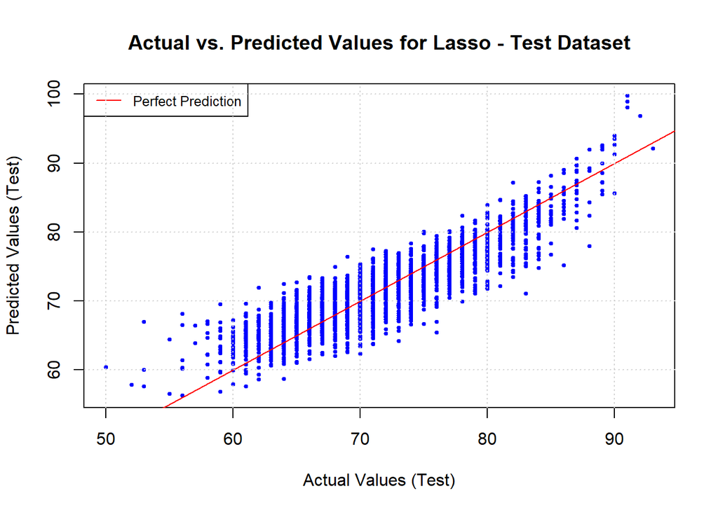

Fig.11:Actual vs. Predicted Values for Lasso

```r
## Lasso Model on Test Data set
pred_test_BQ2_1se<-predict(lasso_model_BQ2_1se, newx =fifa_BQ2_test_x)
rmse_test_BQ2_1se<-sqrt(mean((fifa_BQ2_test_y - pred_test_BQ2_1se)^2))

# Create a scatter plot for Lasso model on the test dataset
plot(fifa_BQ2_test_y, pred_test_BQ2_1se,
     xlab = "Actual Values (Test)",
     ylab = "Predicted Values (Test)",
     main = "Actual vs. Predicted Values for Lasso - Test Dataset",
     pch = 20, # Change the point character to a solid circle
     col = "blue", # Change the color of the points to blue
     cex = 0.7) # Reduce the size of the points

# Add a diagonal line for reference
abline(0, 1, col = "red")

# Add a legend
legend("topleft", legend = "Perfect Prediction", col = "red", lty = 1, cex = 0.8)

# Add a grid
grid()
```

From figure 11, it can be observed that predicted values are close to actual values and randomly distributed around the perfectly predicted values which means the model is working well.

Let’s now check the RMSE values of Lasso model and compare it with Ridge model:

```r
##RMSE values comparison
Lasso_BQ2_df <- data.frame(
  "Ridge: RMSE for Train" = rmse_train_ridge_BQ2_1se,
  "Ridge: RMSE for Test" = rmse_test_ridge_BQ2_1se,
  "Lasso: RMSE for Train" = rmse_train_BQ2_1se,
  "Lasso: RMSE for Test" = rmse_test_BQ2_1se
)

Lasso_BQ2_df_transposed <- t(Lasso_BQ2_df)

# Generate the table
table_5 <- knitr::kable(Lasso_BQ2_df_transposed, align = "c",
                             caption = "Table 5: RMSE Values for Lasso & Ridge Regression") %>%
              kable_classic(full_width = FALSE)
table_5
```

Table 5: RMSE Values for Lasso & Ridge Regression

| Ridge..RMSE.for.Train | 3.031345 |
| --- | --- |
| Ridge..RMSE.for.Test | 3.017020 |
| Lasso..RMSE.for.Train | 2.999749 |
| Lasso..RMSE.for.Test | 2.973998 |

[figure not shown]

Fig.12:Comparison of Ridge and Lasso Regularization

```r
ridge_train <- rmse_train_ridge_BQ2_1se
ridge_test <- rmse_test_ridge_BQ2_1se
lasso_train <- rmse_train_BQ2_1se
lasso_test <- rmse_test_BQ2_1se

# Define colors for bars
colors <- c("orange", "lightgreen")

# Create the bar plot
# Create the bar plot
barplot(
  height = cbind(c(ridge_train, lasso_train), c(ridge_test, lasso_test)),
  beside = TRUE,
  col = colors,
  main = "Comparison of RMSE Values for Ridge and Lasso Regression",
  ylab = "RMSE",
  names.arg = c("Ridge", "Lasso"),
  ylim = c(0, max(c(ridge_train, ridge_test, lasso_train, lasso_test)) * 1.2),
  cex.names = 0.8,
  width = 0.5# Adjust the size of the names
)

# Add legend at the bottom
legend("topright", legend = c("Train", "Test"), fill = colors, inset = c(0, -0.10), xpd = TRUE)
```

**Result of Question 1:** It can be observed that RMSE values are smaller for Lasso model than Ridge model hence we can prefer Lasso model. However, the RMSE value is a little less for test data set than train data set. This could be because the model might be too complex, leading to poor performance on the training set but better performance on the test set. This can happen when the model is trying to fit noise in the training data.In the next step we can try to use subset selection method to build one more model and then compare it to lasso model that has been built.Other way could be removing some of irrelevant numeric variables in the data set and converting few of the relevant categorical variables like performance in different position variables in numeric variables and use them in the model.

## Question 2: Predict a player’s market value based on key contributing factors using multiple linear regression.

The code snippet provided focuses on preparing a dataset for a multiple linear regression analysis aimed at predicting soccer players’ market values. Initially, We created a custom function designed to standardize all numerical data within the dataset to the numeric type, addressing the diversity of data types (like integers and doubles).Then we implemented processing involves applying the function to convert all integer values to numeric, ensuring uniformity in the dataset’s numerical data. Subsequently, the dataset is cleansed of any rows containing missing values.

After cleaning the data, a correlation matrix is generated from the numeric columns of the dataset. The range is chosen to focus on variables with a strong positive relationship but excluding perfect correlation (which is represented by a coefficient of 1). The next step involves extracting and listing the variable names that exhibit high correlation.

```r
# Converting integer values into numeric values
convert_int_to_numeric <- function(x) {
  if(is.integer(x) | is.double(x) ) {
    as.numeric(x)
  } else {
    x
  }
}
# Applying the function to relevant columns
fifa_df <- fifa_df %>%
  mutate_if(is.integer, convert_int_to_numeric)
fifa_df_cleaned <- na.omit(fifa_df)
# Calculate the correlation matrix
cor_matrix <- cor(fifa_df_cleaned %>% select_if(is.numeric))

# Find pairs of variables with correlation above 0.5
high_correlation_pairs <- which(cor_matrix > 0.5 & cor_matrix < 1, arr.ind = TRUE)

# Extract variable names
high_correlation_vars <- rownames(cor_matrix)[high_correlation_pairs[, 1]]
high_correlation_vars <- unique(c(high_correlation_vars, colnames(cor_matrix)[high_correlation_pairs[, 2]]))

# Display the variables with correlation above 0.5
cat("Variables with correlation above 0.5:\n")
```

```
## Variables with correlation above 0.5:
```

```r
high_correlation_vars
```

```
##  [1] "potential"                   "value_eur"
##  [3] "wage_eur"                    "release_clause_eur"
##  [5] "passing"                     "dribbling"
##  [7] "physic"                      "attacking_crossing"
##  [9] "attacking_short_passing"     "skill_dribbling"
## [11] "skill_curve"                 "skill_long_passing"
## [13] "skill_ball_control"          "movement_reactions"
## [15] "power_shot_power"            "power_long_shots"
## [17] "mentality_vision"            "mentality_composure"
## [19] "overall"                     "international_reputation"
## [21] "weight_kg"                   "attacking_heading_accuracy"
## [23] "power_strength"              "height_cm"
## [25] "shooting"                    "attacking_finishing"
## [27] "attacking_volleys"           "skill_fk_accuracy"
## [29] "movement_agility"            "mentality_positioning"
## [31] "movement_acceleration"       "movement_sprint_speed"
## [33] "movement_balance"            "skill_moves"
## [35] "mentality_penalties"         "pace"
## [37] "mentality_aggression"        "mentality_interceptions"
## [39] "defending_marking_awareness" "defending_standing_tackle"
## [41] "defending_sliding_tackle"    "defending"
## [43] "power_stamina"
```

```r
#Linear regression for predicting the player's market value based on key contributing factors.


# Split the data into training and testing sets
set.seed(42)
indices <- sample(1:nrow(fifa_df_cleaned), size = 0.7 * nrow(fifa_df_cleaned))  # Adjust the split ratio if needed
train_data <- fifa_df_cleaned[indices, ]
test_data <- fifa_df_cleaned[-indices, ]

features <- train_data %>% select(high_correlation_vars)
target <- train_data$value_eur
features1 <- features %>% select(-value_eur)



# Build a linear regression model
model <- lm(target ~ ., data = features1)

# Make predictions on the training set
train_predictions <- predict(model, newdata = features1)

# Calculate R-squared on the training set
train_r_squared <- (cor(train_predictions, train_data$value_eur)^2)*100

# Display the R-squared value
cat(paste("Training R-squared:", round(train_r_squared, 4), "%\n"))
```

```
## Training R-squared: 98.9202 %
```

```r
test_features <- test_data %>% select(high_correlation_vars)
test_target <- test_data$value_eur
test_features1 <- test_data %>% select(-value_eur)
# Make predictions on the test set
predictions <- predict(model, newdata = test_features1)

length(predictions)
```

```
## [1] 4474
```

```r
# Evaluate the model
mse <- mean((predictions - test_target)^2)
r_squared <- (1 - mse / var(test_target))*100

# Display model performance metrics
cat(paste("Mean Squared Error:", mse, "\n"))
```

```
## Mean Squared Error: 400705438651.271
```

```r
cat(paste("R-squared:", round(r_squared,4), "%\n"))
```

```
## R-squared: 98.8622 %
```

```r
# Create a data frame for plotting
plot_data <- data.frame(Actual = test_target, Predicted = predictions, Residuals = predictions - test_target)
```

The scatter plot visualizes the relationship between the actual market values of players (on the x-axis) and the values predicted by the linear regression model (on the y-axis). The closer the points are to the dashed green line, which represents a perfect prediction, the more accurate the model. The solid yellow line, representing the best fit line from the regression, is very close to this perfect prediction line, which indicates a high degree of accuracy in the model’s predictions. The spread of the purple points suggests that the model predicts lower values quite well but shows some variance as the market value increases. The model appears to be performing well, given the high concentration of points near the line of perfect prediction.

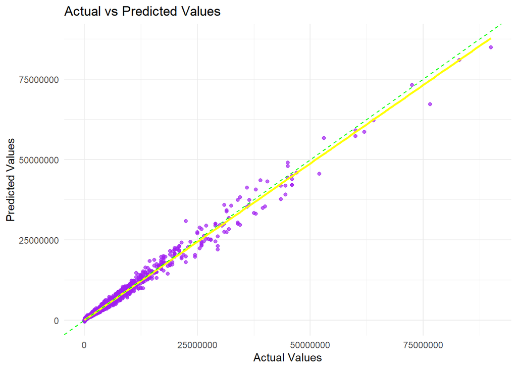

```r
# Scatter plot with regression line
scatter_plot = ggplot(plot_data, aes(x = Actual, y = Predicted)) +
  geom_point(color = "purple", alpha = 0.7) +
  geom_smooth(method = "lm", se = FALSE, color = "yellow") +
  geom_abline(intercept = 0, slope = 1, linetype = "dashed", color = "green") +
  labs(title = "Actual vs Predicted Values",
       x = "Actual Values",
       y = "Predicted Values") +
  theme_minimal()
scatter_plot
```

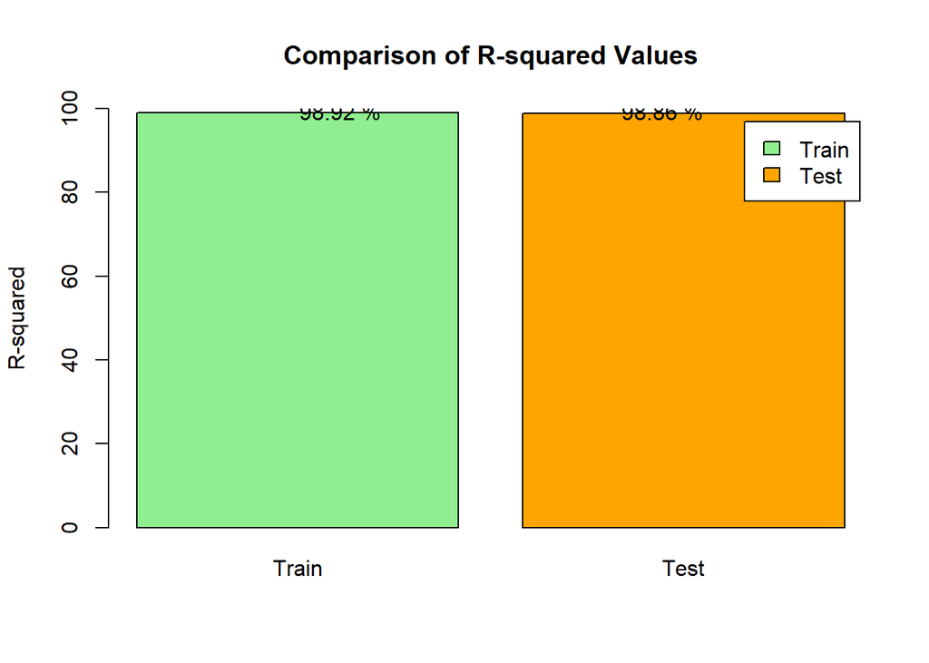

```r
# Combine R-squared values
r_squared_values <- c(Train = train_r_squared, Test = r_squared)

# Create a bar plot
barplot(r_squared_values, col = c("lightgreen", "orange"), main = "Comparison of R-squared Values",
        ylim = c(0, 100), ylab = "R-squared", beside = TRUE, legend.text = TRUE)

# Add labels with improved positioning
text(x = c(1, 2), y = r_squared_values + 0.008,
     labels = paste(round(r_squared_values, 2), "%"), pos = 2, cex = 0, col = "black")
```

A multiple linear regression model with a training dataset R-squared value of 98.92% and a test dataset R-squared value of 98.86% suggests that the model performs exceptionally well in explaining the variance in the dependent variable. The high R-squared values indicate that the model captures a significant proportion of the variability in the target variable, showcasing its effectiveness in fitting the training data and generalizing well to unseen test data.

Typically, a high R-squared on the training dataset coupled with a similar performance on the test dataset suggests that the model has not overfit the training data and is likely to perform well on new, unseen data..

In summary, based on the provided R-squared values, the multiple linear regression model appears to be strong, demonstrating high predictive power and generalization ability on both the training and test datasets.

### Question 3: Predict whether the player should be classified as a high-wage player or a low-wage player using logistic regression.

We set a location for a CSV file and then read the data from this file into the R environment, creating a data structure ready for analysis.

Then, We used a function to generate a summary of the dataset, which includes statistical summaries for each variable, such as mean, median, minimum, and maximum values, as well as counts for categorical variables. This provides a quick overview of the data’s characteristics.

```r
summary(data)
```

[output not shown]

To identify the presence of missing values across the dataset, We employed a two-step approach. Initially, I utilized a function to assess each element in the dataset for missing values, producing a boolean matrix that indicates the presence of missing data. Subsequently, We aggregated this information at the column level to quantify the total number of missing values per variable.

```r
na_values <- is.na(data)
colSums(na_values)
```

```
##                   sofifa_id                  short_name
##                           0                           0
##            player_positions                     overall
##                           0                           0
##                   potential                   value_eur
##                           0                         250
##                    wage_eur                         age
##                         240                           0
##                   height_cm                   weight_kg
##                           0                           0
##                club_team_id                   club_name
##                         240                           0
##                 league_name                league_level
##                           0                         625
##               club_position                 club_joined
##                           0                        1288
##   club_contract_valid_until              nationality_id
##                         240                           0
##            nationality_name              preferred_foot
##                           0                           0
##                   weak_foot                 skill_moves
##                           0                           0
##    international_reputation                   body_type
##                           0                           0
##          release_clause_eur                        pace
##                        1298                        2061
##                    shooting                     passing
##                        2061                        2061
##                   dribbling                   defending
##                        2061                        2061
##                      physic          attacking_crossing
##                        2061                           0
##         attacking_finishing  attacking_heading_accuracy
##                           0                           0
##     attacking_short_passing           attacking_volleys
##                           0                           0
##             skill_dribbling                 skill_curve
##                           0                           0
##           skill_fk_accuracy          skill_long_passing
##                           0                           0
```

[output cut: 41 more lines]

```
##                           0                           0
##                         ldm                         cdm
##                           0                           0
##                         rdm                         rwb
##                           0                           0
##                          lb                         lcb
##                           0                           0
##                          cb                         rcb
##                           0                           0
##                          rb                          gk
##                           0                           0
##            General_Position                   Footdummy
##                           0                           0
##               injury_player
##                           0
```

Recognizing the limited predictive value of existing categorical variables such as the player’s preferred foot, position, league, and nationality, We decided to introduce a new categorical variable aimed at enhancing the dataset’s analytical utility. This variable delineates players based on their wage, categorizing them into two distinct groups. To achieve this, We first determined a wage threshold by analyzing the median wage(Used 50 th percentile to avoid class bias), thereby ensuring resilience to outliers and a balanced categorization criterion. Players earning above this threshold were assigned to one category, signifying a higher wage, while those below were categorized accordingly. This new variable is intended to serve as a more meaningful target for prediction models, facilitating a nuanced exploration of factors influencing player remuneration. Following the creation of this variable, the original wage data was removed to streamline the dataset for analysis focused on this newly defined classification.

```r
good_wage_threshold <- quantile(data$wage_eur, 0.5, na.rm = TRUE)
data$good_wage <- ifelse(data$wage_eur > good_wage_threshold, 1, 0)
data$wage_eur <- NULL
```

Acknowledging the significant role a player’s position plays in their wage potential, I opted to further refine the dataset by incorporating a new column that categorizes players based on their positions. This decision was driven by the understanding that a player’s position is a key determinant of their value and, consequently, their earnings. To implement this, I employed a transformation that assigns numerical values to different general positions—goalkeepers, defenders, midfielders, and attackers—reflecting a structured approach to represent these categories. This method allows for the nuanced inclusion of positional data, highlighting its importance in analyses focused on understanding wage disparities among players.

```r
#library(dplyr)

data <- data %>%
  mutate(new_column = case_when(
    General_Position == "Goalkeeper" ~ 0,
    General_Position == "Defender" ~ 1,
    General_Position == "Midfielder" ~ 2,
    General_Position == "Attacker" ~ 3,
    TRUE ~ NA_real_
  ))
```

In this part of the code, I initiated a process to pinpoint the specific rows within the dataset where the ‘value_eur’ column contains missing values. This preparatory step is crucial as it lays the groundwork for a targeted approach to handling missing data.

```r
missing_indices_before <- which(is.na(data$value_eur))
missing_indices_before
```

```
##   [1]   329   330   409   410   411   412   567   568   569   725   751   752
##  [13]   753   754   763   783   813   883   927   992   993   994  1023  1184
##  [25]  1251  1252  1253  1254  1256  1261  1280  1327  1339  1386  1450  1611
##  [37]  1612  1613  1615  1616  1617  1618  1680  1738  1939  1942  2124  2125
##  [49]  2178  2218  2267  2345  2352  2393  2400  2463  2489  2537  2655  2657
##  [61]  2696  2702  2737  2749  2791  2806  2916  2965  3039  3111  3174  3292
##  [73]  3293  3294  3374  3475  3517  3544  3562  3570  3583  3610  3765  3766
##  [85]  3780  3824  3904  3918  4021  4046  4047  4228  4235  4284  4308  4350
##  [97]  4375  4395  4400  4418  4776  4806  4818  4819  4996  5055  5088  5175
## [109]  5286  5314  5329  5369  5386  5644  5661  5662  5663  5664  5665  5736
## [121]  5850  5875  5876  5889  5956  6078  6080  6195  6314  6316  6429  6605
## [133]  6609  6619  6632  6638  6639  6640  6654  6869  6886  7011  7017  7111
## [145]  7185  7248  7411  7481  7614  7689  7710  7711  7717  7732  7768  7793
## [157]  7926  8045  8112  8178  8190  8241  8385  8481  8558  8729  8749  8751
## [169]  8762  8763  8774  8775  8873  9193  9197  9477  9479  9601  9605  9653
## [181]  9820  9929  9955 10148 10521 10551 10616 10666 10672 10857 11041 11043
## [193] 11092 11276 11314 11647 11881 12151 12227 12249 12250 12297 12316 12441
## [205] 12709 12773 13123 13175 13176 13326 13347 13356 13614 13822 13923 14058
## [217] 14059 14060 14093 14099 14384 14722 14875 15196 15337 15341 15412 15413
## [229] 15414 15415 15416 15417 15456 15776 15961 15975 15976 15977 15978 16015
## [241] 16022 16467 16468 16469 16470 16471 16509 16839 16861 18375
```

Using the ‘mice’ function with predictive mean matching (PMM) method, we executed a single imputation cycle with concise iterations, balancing computational efficiency with the quality of imputation, and set a seed for reproducibility. The imputed values were then used to fill in the missing ‘value_eur’ data.

### Why predicting in value_eur column ?

The decision to predict missing values in the ‘value_eur’ column was informed by its strong correlation and causation relationship with the wage column, indicating that players’ market values (value_eur) significantly influence their wages. This relationship suggests that understanding and accurately imputing the ‘value_eur’ can provide insightful data points for analyses, particularly when assessing financial aspects of players’ careers.

Additionally, the target variable for our analysis—identified by the newly created categorical ‘good_wage’ column—along with the relatively low incidence of missing values in other columns, reinforced the strategic choice to focus on ‘value_eur’ for imputation. This approach ensures that the dataset remains robust and comprehensive, allowing for more accurate modeling and interpretation of players’ wages based on their market values.

```r
library(mice)
temp_data <- data[, c("value_eur", "overall", "potential", "age", "nationality_id", "international_reputation"), drop = FALSE]

temp_data[sapply(temp_data, is.character)] <- lapply(temp_data[sapply(temp_data, is.character)], as.factor)

imputed <- mice(temp_data, method = 'pmm', m = 1, maxit = 5, seed = 123)
completed <- complete(imputed)

data$value_eur[is.na(data$value_eur)] <- completed$value_eur[is.na(data$value_eur)]
```

In this phase, we revisited the rows initially identified with missing ‘value_eur’ values to evaluate the effectiveness of our imputation strategy. By extracting these specific rows from the dataset—now with the imputed values in place—we were able to directly observe the outcomes of the imputation process. Utilizing a print command, we displayed the updated rows to assess the quality of the imputed data. This step is critical for validating the imputation model’s performance, ensuring that the filled-in values are consistent with the dataset’s overall patterns and distributions.

```r
data_imputed_rows <- data[missing_indices_before, ]
head(data_imputed_rows)
```

|  | sofifa_id | short_name | player_positions | overall | potential | value_eur | age | height_cm | weight_kg | club_team_id | club_name | league_name | league_level | club_position | club_joined | club_contract_valid_until | nationality_id | nationality_name | preferred_foot | weak_foot | skill_moves | international_reputation | body_type | release_clause_eur | pace | shooting | passing | dribbling | defending | … |
| --- | --- | --- | --- | --- | --- | --- | --- | --- | --- | --- | --- | --- | --- | --- | --- | --- | --- | --- | --- | --- | --- | --- | --- | --- | --- | --- | --- | --- | --- | --- |
| 329 | 245309 | E. Schetino | CB | 82 | 82 | 2700000 | 27 | 185 | 80 | NA |  |  | NA |  | NA | NA | 60 | Uruguay | Right | 3 | 2 | 1 | Normal (185+) | NA | 80 | 43 | 56 | 65 | 83 | … |
| 330 | 245313 | J. Sildero | CAM, RM | 82 | 82 | 1100000 | 27 | 177 | 75 | NA |  |  | NA |  | NA | NA | 60 | Uruguay | Right | 4 | 4 | 1 | Normal (170-185) | NA | 81 | 77 | 81 | 82 | 40 | … |
| 409 | 245299 | J. Frendado | CB, CDM | 81 | 81 | 1100000 | 35 | 181 | 82 | NA |  |  | NA |  | NA | NA | 60 | Uruguay | Right | 3 | 2 | 1 | Normal (170-185) | NA | 71 | 61 | 57 | 62 | 82 | … |
| 410 | 245304 | S. Ardero | CAM, LM, LW | 81 | 81 | 8000000 | 31 | 171 | 63 | NA |  |  | NA |  | NA | NA | 60 | Uruguay | Left | 5 | 4 | 1 | Lean (170-185) | NA | 82 | 72 | 77 | 83 | 26 | … |
| 411 | 245305 | L. Dálves | ST, CF | 81 | 81 | 1800000 | 27 | 188 | 83 | NA |  |  | NA |  | NA | NA | 60 | Uruguay | Right | 3 | 3 | 1 | Normal (185+) | NA | 80 | 82 | 60 | 71 | 34 | … |
| 412 | 251700 | S. Mandíquez | ST | 81 | 81 | 11000000 | 30 | 188 | 84 | NA |  |  | NA |  | NA | NA | 57 | Ecuador | Right | 4 | 4 | 2 | Stocky (185+) | NA | 80 | 80 | 56 | 74 | 29 | … |

Following the imputation process, we conducted a final check to confirm the elimination of missing values in the ‘value_eur’ column. This verification step is crucial to ensure that all previously identified missing values in the ‘value_eur’ column have been successfully addressed.

```r
na_values <- is.na(data)
colSums(na_values)
```

```
##                   sofifa_id                  short_name
##                           0                           0
##            player_positions                     overall
##                           0                           0
##                   potential                   value_eur
##                           0                           0
##                         age                   height_cm
##                           0                           0
##                   weight_kg                club_team_id
##                           0                         240
##                   club_name                 league_name
##                           0                           0
##                league_level               club_position
##                         625                           0
##                 club_joined   club_contract_valid_until
##                        1288                         240
##              nationality_id            nationality_name
##                           0                           0
##              preferred_foot                   weak_foot
##                           0                           0
##                 skill_moves    international_reputation
##                           0                           0
##                   body_type          release_clause_eur
##                           0                        1298
##                        pace                    shooting
##                        2061                        2061
##                     passing                   dribbling
##                        2061                        2061
##                   defending                      physic
##                        2061                        2061
##          attacking_crossing         attacking_finishing
##                           0                           0
##  attacking_heading_accuracy     attacking_short_passing
##                           0                           0
##           attacking_volleys             skill_dribbling
##                           0                           0
##                 skill_curve           skill_fk_accuracy
##                           0                           0
##          skill_long_passing          skill_ball_control
##                           0                           0
```

[output cut: 41 more lines]

```
##                           0                           0
##                         cdm                         rdm
##                           0                           0
##                         rwb                          lb
##                           0                           0
##                         lcb                          cb
##                           0                           0
##                         rcb                          rb
##                           0                           0
##                          gk            General_Position
##                           0                           0
##                   Footdummy               injury_player
##                           0                           0
##                   good_wage                  new_column
##                         240                         368
```

In this step, we focused on ensuring that our dataset does not suffer from sample bias, particularly in the context of the newly created ‘good_wage’ classification. The printout of these counts revealed that there are 9596 instances of class 0 and 8647 instances of class 1. This distribution indicates a relatively balanced representation of both low and high wage categories within the dataset, which is crucial for preventing sample bias. Ensuring a balanced class distribution is important for the reliability of Logistic Regression, as it helps to avoid skewing the results in favor of one category over the other.

```r
value_counts_good_wage <- table(data$good_wage)
print(value_counts_good_wage)
```

```
##
##    0    1
## 9596 8647
```

```r
numeric_columns <- sapply(data, is.numeric)
data[numeric_columns] <- lapply(data[numeric_columns], function(x) ifelse(is.na(x), median(x, na.rm = TRUE), x))
```

### Feature selection

In the feature selection step, the focus was on identifying columns within the dataset that show a significant correlation with our target column, the ‘good_wage’ classification. This process is pivotal in refining the dataset to include only those variables that have a meaningful relationship with the target, thereby enhancing the efficacy of any predictive modeling or analysis to be conducted later.

By calculating the correlation coefficient between each numeric column and the ‘good_wage’ column, we were able to assess the strength and direction of the relationship between these variables. The selection of significant features was based on a predefined threshold for the correlation coefficient, in this case, an absolute value greater than 0.2. This threshold was chosen to capture features that have at least a moderate relationship with the target variable, excluding those with negligible correlations. The resulting `significant_features` variable contains the names of columns that meet this criterion, streamlining the dataset to focus on variables that are most likely to contribute meaningful insights in relation to the ‘good_wage’ outcome.

```r
correlations <- sapply(data[, numeric_columns], function(x) cor(x, data$good_wage, use = "complete.obs"))
significant_features <- names(correlations[abs(correlations) > 0.2])
print(significant_features)
```

```
##  [1] "sofifa_id"                  "overall"
##  [3] "potential"                  "value_eur"
##  [5] "age"                        "club_team_id"
##  [7] "skill_moves"                "international_reputation"
##  [9] "release_clause_eur"         "shooting"
## [11] "passing"                    "dribbling"
## [13] "physic"                     "attacking_crossing"
## [15] "attacking_finishing"        "attacking_heading_accuracy"
## [17] "attacking_short_passing"    "attacking_volleys"
## [19] "skill_dribbling"            "skill_curve"
## [21] "skill_fk_accuracy"          "skill_long_passing"
## [23] "skill_ball_control"         "movement_reactions"
## [25] "power_shot_power"           "power_stamina"
## [27] "power_strength"             "power_long_shots"
## [29] "mentality_aggression"       "mentality_positioning"
## [31] "mentality_vision"           "mentality_penalties"
## [33] "mentality_composure"        "good_wage"
```

After a thorough analysis of the dataset and evaluating the correlations between various columns and the target variable, a decision was made to focus on columns that exhibit not just high correlation but also significant causation with the ‘good_wage’ classification. This approach underscores the importance of distinguishing between correlation.

The columns identified as having high causation—overall rating, potential, market value (‘value_eur’), age, nationality (represented by ‘nationality_id’), international reputation, and a newly created column reflecting players’ positions—were chosen for further analysis. This selection is based on the rationale that these factors are intrinsically linked to a player’s wage, either through their on-field performance, market value, experience, or reputation on the international stage.

Notably, the decision to exclude certain columns despite their correlation exceeding the 0.2 threshold, such as ‘skill_curve’, was made on the grounds of relevance and logical causation. In this context, ‘skill_curve’ was deemed not to have a direct impact on a player’s wage, suggesting that its correlation with the ‘good_wage’ variable might be incidental or due to underlying factors not directly related to the skill itself.

This selective approach, prioritizing causation over mere correlation, ensures that the analysis is grounded in variables that are logically and directly relevant to player wages. By focusing on these causation variables, the aim is to build a more accurate and meaningful model that reflects the true drivers behind players’ wages, avoiding the potential noise and bias that might arise from including variables with no logical causation. This methodical selection process is crucial for developing robust analyses and interpretations that can inform further discussions and decisions regarding player valuation and wage determination.

```r
selected_columns <- c("overall", "potential", "value_eur", "age", "nationality_id", "international_reputation", "new_column", "good_wage")
data <- data[selected_columns]
```

### Multicollinairt check

During the multicollinearity check, it was discovered that ‘overall’ and ‘potential’ exhibit a high degree of correlation, suggesting that including both in the model might introduce redundancy and affect the model’s reliability. Multicollinearity can inflate the variance of the coefficient estimates and make the model interpretation more challenging.

To address this issue, a variance inflation factor (VIF) analysis was conducted using the ‘car’ package in R, which helps quantify the level of multicollinearity among the independent variables in a regression model. The VIF values for the initial set of selected variables indicated that ‘overall’ had a high VIF value, suggesting significant multicollinearity.

```r
#library(car)

selected_columns_forvif <- c("overall", "potential", "value_eur", "age", "nationality_id", "international_reputation")

dataforvif <- data[selected_columns_forvif]

model_for_vif <- lm(as.formula(paste("good_wage ~", paste(selected_columns_forvif, collapse = " + "))), data = data)

vif_values <- car::vif(model_for_vif)
print(vif_values)
```

```
##                  overall                potential                value_eur
##                 7.770736                 5.882132                 2.571596
##                      age           nationality_id international_reputation
##                 4.600122                 1.040578                 1.808630
```

Based on these results, a decision was made to re-evaluate the model without the ‘overall’ variable to reduce multicollinearity. By excluding ‘overall’ and retaining ‘potential’ along with the other selected variables—‘value_eur’, ‘age’, ‘nationality_id’, and ‘international_reputation’—a new VIF analysis was conducted to assess the impact on multicollinearity.We ensured that the model is built on a set of variables that provide unique and valuable insights into the factors influencing the ‘good_wage’ classification, thereby improving the robustness and reliability of the analysis.

```r
selected_columns_forvif <- c( "potential", "value_eur", "age", "nationality_id", "international_reputation")

dataforvif <- data[selected_columns_forvif]

model_for_vif <- lm(as.formula(paste("good_wage ~", paste(selected_columns_forvif, collapse = " + "))), data = data)

vif_values <- car::vif(model_for_vif)
print(vif_values)
```

```
##                potential                value_eur                      age
##                 1.837294                 2.226883                 1.278772
##           nationality_id international_reputation
##                 1.040071                 1.768707
```

In this code snippet, the process of splitting the dataset into training and testing sets is undertaken, a fundamental step in preparing data for machine learning models. The parameter `p = .8` indicates that 80% of the data is allocated to the training set, with the remaining 20% going to the testing set. This split ratio is a common practice, allowing for a substantial amount of data to be used for model training while still retaining a meaningful portion for testing the model’s performance on unseen data. This methodical separation ensures that the model can be trained on one subset of the data and then evaluated on a distinct subset, providing a reliable assessment of its performance and generalizability to new data.

```r
library(caret)
set.seed(123)
trainIndex <- createDataPartition(data$good_wage, p = .8,
                                  list = FALSE,
                                  times = 1)
train_data <- data[trainIndex, ]
test_data <- data[-trainIndex, ]
```

### Logistic Regression

For the initial attempt at a logistic regression model, the model is formulated to predict the ‘good_wage’ variable using the selected predictors. This model is trained on the training dataset. This approach enables the assessment of the relationship between the selected predictors and the likelihood of having a good wage, applying logistic regression principles to estimate the probabilities that reflect this binary outcome.

```r
model_formula <- as.formula(paste("good_wage ~", paste(selected_columns_forvif, collapse = " + ")))
logistic_model <- glm(model_formula, data = train_data, family = "binomial")
```

This code snippet demonstrates how to generate predictions from the logistic regression model and evaluate its performance on the test dataset. The accuracy of predictions is calculated by comparing them to the actual ‘good_wage’ values in the test dataset, with the result showing an accuracy of approximately 78.6%. This metric provides a straightforward measure of the model’s overall predictive capability. To further assess the model’s performance, the area under the Receiver Operating Characteristic (ROC) curve (AUC) is calculated using the `pROC` package. The resulting AUC value of approximately 0.873 indicates a high level of model performance, suggesting that the logistic regression model is effective in distinguishing between players with a good wage and those without, based on the predictors included in the model.

```r
predictions <- predict(logistic_model, newdata = test_data, type = "response")

predicted_classes <- ifelse(predictions > 0.5, 1, 0)

accuracy <- mean(predicted_classes == test_data$good_wage)
print(paste("Accuracy:", accuracy))
```

```
## [1] "Accuracy: 0.785984848484849"
```

```r
if(!require(pROC)) install.packages("pROC")
library(pROC)
roc_curve <- roc(test_data$good_wage, predictions)
auc_value <- auc(roc_curve)
print(paste("AUC:", auc_value))
```

```
## [1] "AUC: 0.873305929221991"
```

```r
predicted_classes_factor <- factor(predicted_classes, levels = c(0, 1))
actual_classes_factor <- factor(test_data$good_wage, levels = c(0, 1))

conf_matrix_caret <- confusionMatrix(predicted_classes_factor, actual_classes_factor)
print(conf_matrix_caret)
```

```
## Confusion Matrix and Statistics
##
##           Reference
## Prediction    0    1
##          0 1700  522
##          1  269 1205
##
##                Accuracy : 0.786
##                  95% CI : (0.7724, 0.7991)
##     No Information Rate : 0.5327
##     P-Value [Acc > NIR] : < 0.00000000000000022
##
##                   Kappa : 0.5662
##
##  Mcnemar's Test P-Value : < 0.00000000000000022
##
##             Sensitivity : 0.8634
##             Specificity : 0.6977
##          Pos Pred Value : 0.7651
##          Neg Pred Value : 0.8175
##              Prevalence : 0.5327
##          Detection Rate : 0.4600
##    Detection Prevalence : 0.6012
##       Balanced Accuracy : 0.7806
##
##        'Positive' Class : 0
##
```

Following the evaluation of the logistic regression model using accuracy and the confusion matrix, the Receiver Operating Characteristic (ROC) curve analysis offers an additional, insightful perspective on the model’s performance. The ROC curve’s area under the curve (AUC) value of approximately 0.87 is a key metric that quantifies the overall ability of the model to discriminate between the two classes across all possible thresholds.

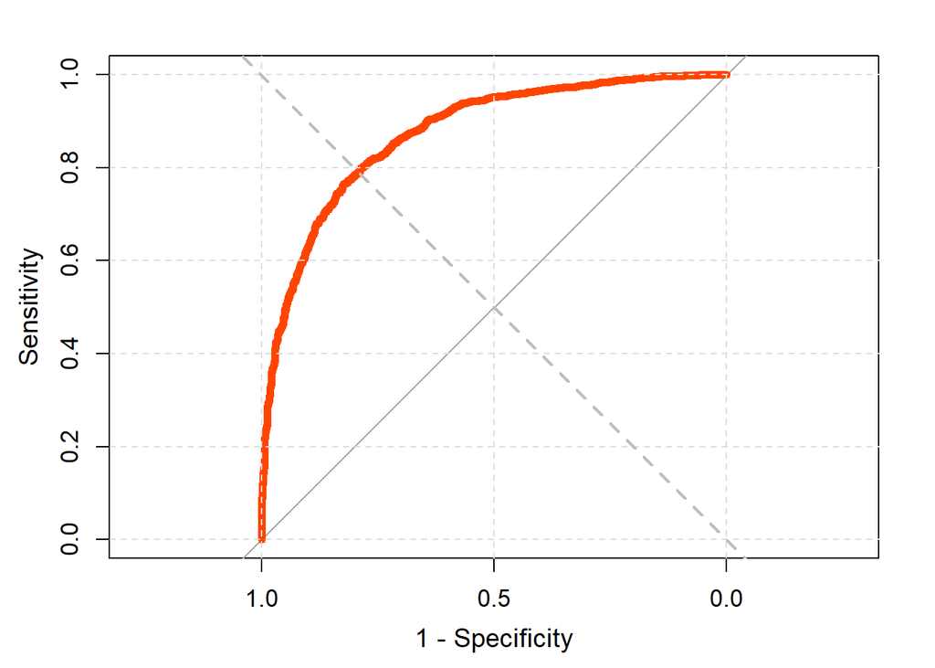

```r
actualClasses <- factor(test_data$good_wage, levels = c(0, 1))

roc_curve <- roc(response = actualClasses,
                 predictor = predictions,
                 levels = c(1, 0))
plot(roc_curve,
     col = "#FF4500", lwd = 2,
     type = "b",
     pch = 19,
     xlab = "1 - Specificity",
     ylab = "Sensitivity",
     cex.lab = 1.2,
     cex.main = 1.5,
     cex.axis = 1.1,
     cex = 0.6)

grid(col = "#DDDDDD", lty = 2)
abline(0, 1, col = "grey", lwd = 2, lty = 2)
```

###Threshold optimiztion

In this segment, the logistic regression model is re-evaluated to find the optimal threshold for classifying observations. After fitting the model on the training data, predictions are made on the same set to identify the threshold that yields the highest accuracy. By iterating over a range of thresholds, the best one is determined based on its ability to maximize accuracy in distinguishing between classes. Upon applying this optimized threshold to the test dataset, the model achieved a test data accuracy of approximately 79.1%, indicating a very slight improvement in its ability to classify observations correctly compared to the initial threshold of 0.5. The model’s goodness-of-fit, as measured by the Akaike Information Criterion (AIC), was reported as 13299.49. Furthermore, the Area Under the Curve (AUC) for the Receiver Operating Characteristic (ROC) curve was calculated as approximately 0.873( so close to previous one), maintaining a strong performance in discriminating between the two classes (good wage vs. not good wage) across all thresholds.

```r
model_formula <- as.formula(paste("good_wage ~", paste(selected_columns_forvif, collapse = " + ")))
logistic_model <- glm(model_formula, data = train_data, family = "binomial")

train_predictions <- predict(logistic_model, newdata = train_data, type = "response")

best_threshold <- 0.5
best_accuracy <- 0

for(threshold in seq(0.1, 0.9, by = 0.01)) {
  predicted_classes <- ifelse(train_predictions > threshold, 1, 0)
  accuracy <- mean(predicted_classes == train_data$good_wage)

  if(accuracy > best_accuracy) {
    best_accuracy <- accuracy
    best_threshold <- threshold
  }
}

test_predictions <- predict(logistic_model, newdata = test_data, type = "response")
test_predicted_classes <- ifelse(test_predictions > best_threshold, 1, 0)

test_accuracy <- mean(test_predicted_classes == test_data$good_wage)
print(paste("Test Data Accuracy:", test_accuracy))
```

```
## [1] "Test Data Accuracy: 0.790854978354978"
```

```r
model_aic <- AIC(logistic_model)
print(paste("Model AIC:", model_aic))
```

```
## [1] "Model AIC: 13299.4909444574"
```

```r
if(!require(pROC)) install.packages("pROC")
library(pROC)
roc_curve <- roc(test_data$good_wage, test_predictions)
auc_value <- auc(roc_curve)
print(paste("AUC:", auc_value))
```

```
## [1] "AUC: 0.873305929221991"
```

```r
best_threshold
```

```
## [1] 0.44
```

### Conclusion of logistic regression

The conclusion drawn from the analysis presents a thoughtful consideration of the balance between two types of errors in player selection for companies: choosing less potential players (false positives) versus missing out on highly valuable future stars (false negatives). The assessment underscores that the cost of not recognizing a potentially star player is deemed more significant than the risk associated with recruiting a player with less potential. This perspective is crucial for talent management strategies, where the emphasis is on securing players who could provide substantial future value.

Despite the logical inclination to adjust the threshold above 0.5 to minimize the risk of missing out on valuable players, empirical evidence from the model’s performance indicates that decreasing the threshold(0.44 is best threshold) slightly improves the model’s accuracy. This finding suggests a counterintuitive situation where lowering the threshold, contrary to increasing it as initially thought, might be beneficial for model performance.

However, given the minimal impact on the outcome from adjusting the threshold and the inherent trade-offs between increasing and decreasing it, the decision to stick with the initial threshold of 0.5 is deemed a logical compromise. This choice represents an equilibrium point that, while not perfectly aligning with the intuitive strategy to increase the threshold, acknowledges the empirical evidence suggesting slight improvements with a lower threshold.

## Question 4: Test whether there is a significant difference in overall ratings between players from Europe and South America.

Null Hypothesis (H0): The mean overall ratings of players of European countries are not different to those of South American countries players.

Alternative Hypothesis (H1): The mean overall ratings of players of European counties are different from those of South American countries players.

```r
# Load required libraries
library(dplyr)
```

Loading the Dataset and defining Europe and South america countries

```r
# Load the dataset
fifa_data <- read.csv("outputplayers20.csv")

# Define European and South American countries
european_countries <- c("Spain", "Italy", "Germany", "France", "England", "Netherlands", "Portugal", "Belgium", "Switzerland", "Austria", "Scotland", "Denmark", "Sweden", "Norway", "Finland", "Ireland", "Wales", "Czech Republic", "Greece", "Turkey", "Russia", "Poland", "Ukraine", "Hungary", "Croatia", "Serbia", "Bosnia and Herzegovina", "Slovakia", "Romania", "Bulgaria", "Albania", "Lithuania", "Slovenia", "Latvia", "Estonia", "Montenegro", "Luxembourg", "Cyprus", "Malta", "Iceland", "Faroe Islands", "Greenland", "Liechtenstein", "Andorra", "Monaco", "San Marino", "Gibraltar")
south_american_countries <- c("Brazil", "Argentina", "Colombia", "Peru", "Venezuela", "Chile", "Ecuador", "Bolivia", "Paraguay", "Uruguay", "Guyana", "Suriname", "French Guiana", "Falkland Islands")
```

Then filtering Players of Europe and South america countries

```r
# Filter data for European and South American players
european_players <- fifa_data %>% filter(nationality_name %in% european_countries)
south_american_players <- fifa_data %>% filter(nationality_name %in% south_american_countries)
```

```r
# Perform two-sample t-test assuming equal variances
t_test_result <- t.test(european_players$overall, south_american_players$overall, var.equal = TRUE)

# Print the results
print(t_test_result)
```

```
##
##  Two Sample t-test
##
## data:  european_players$overall and south_american_players$overall
## t = -16.512, df = 13871, p-value < 0.00000000000000022
## alternative hypothesis: true difference in means is not equal to 0
## 95 percent confidence interval:
##  -2.606334 -2.053198
## sample estimates:
## mean of x mean of y
##  66.24372  68.57349
```

**Interpretation of hypothesis test**

data: european_players$overall and south_american_players$overall: This indicates the two samples being compared.

Degrees of Freedom: df = 13871: Here the number of independent observations in the data that are available

P-value: p-value < 2.2e-16 the p-value is extremely small, indicating very strong evidence against the null hypothesis.

Alternative Hypothesis: True difference in means is not equal to 0:It states that the true difference in means between European players and South American players is not equal to zero.

Confidence Interval: 95 percent confidence interval: -2.606334 -2.053198; This is the 95% confidence interval for the difference in means between the two samples.The confidence interval is negative, suggesting that European players, on average, have lower overall ratings than South American players.

The results of the two-sample t-test indicate a significant disparity in the overall ratings between European and South American players. Specifically, South American players exhibit higher mean overall ratings compared to their European counterparts. The notably small p-value suggests compelling evidence against the null hypothesis, reinforcing the observed difference in ratings.

**The results of the hypothesis test indicate:**

- Reject H0 $: The p-value is less than the chosen significance level (typically 0.05), providing strong evidence against the null hypothesis.
- Accept H1 : This suggests that there is a significant difference in mean overall ratings between European and South American players.

  Therefore, we conclude that there is a significant, non-random difference in the mean ratings between the two regions. Specifically, South American players have higher mean overall ratings compared to European players.

# Conclusion

In conclusion, we revisited several pivotal questions that underpin the business operations within the world of soccer, applying rigorous statistical models to extract valuable insights.

**Question 1:** “Predict the potential of the players to identify emerging talents using regularization method” , The business implication of this is profound, as soccer clubs can leverage our model to discern whether a player is a sound investment. Our exploration began with ridge regularization, which did not sufficiently simplify the model. However, our analysis favored the Lasso model, which demonstrated superior predictive performance by achieving lower RMSE values. This suggests that Lasso regression’s ability to reduce complexity through feature selection makes it the preferred method. Yet, the slightly lower RMSE for the test data implies that further refinement, such as subset selection or revising the variable set, could enhance the model’s effectiveness.

**Question 3** : “Predict whether the player should be classified as a high-wage player or a low-wage player using logistic regression”, This is especially crucial for sponsors and management companies in forecasting future wage trends and shaping contract negotiations. Our model’s accuracy and AUC score are robust, indicating a powerful classification capability that stakeholders can rely upon for making informed decisions.

**Question 4**: “Test whether there is a significant difference in overall ratings between players from Europe and South America”, The business ramifications are significant for entities considering where to invest in player development infrastructure. Our statistical tests uncovered a notable difference in ratings, with South American players showing higher mean overall ratings than European players. This insight, supported by a low p-value, provides a compelling argument for potential investment shifts toward South American soccer talent.

Together, these questions and their corresponding analyses form a cornerstone of our understanding, offering clubs, managers, sponsors, and investors a data-driven foundation for strategic decision-making in the dynamic and financially significant world of soccer.

# References:

- Nishida, K. (2018, February 23). A Beginner’s Guide to Exploratory Data Analysis with Linear Regression — Part 1. Learn Data Science. https://blog.exploratory.io/a-practical-guide-of-exploratory-data-analysis-with-linear-regression-part-1-9f3a182d7a92
- Chaudhary, H. (2023, Mar 9). Regression project part 3: EDA & creating the model. Medium. Retrieved from https://medium.com/@chaudharyharsh575/regression-project-part-3-eda-creating-the-model-7ad0432387f7
- Wu, S. (2020, May 18). Multicollinearity in Regression: Why it is a problem? How to check and fix it. Towards Data Science. Retrieved from https://towardsdatascience.com/multicollinearity-in-regression-9b48a2fd15ed
- Wijaya, C. Y. (2020, June 24). Outlier — Why is it important? The tale of the extreme data. Towards Data Science. Retrieved from https://towardsdatascience.com/outlier-why-is-it-important-the-tale-of-the-extreme-data-48d25130b23b
- Sports Statistics. (2024). Retrieved from https://sports-statistics.com/sports-data/sports-data-sets-for-data-modeling-visualization-predictions-machine-learning/
- Songara, A. (2022, March 27). Correlation vs Collinearity vs Multicollinearity. Retrieved from https://medium.com/@songaraankit/correlation-vs-collinearity-vs-multicollinearity-b8e4391617af
- Casati, F. (2022, October 4). Train-Test Data Split. Retrieved from https://medium.com/@sphoebs/train-test-data-split-99b43492cc56
- Moody, J. (2019, September 5). What does RMSE really mean? Towards Data Science. Retrieved from the Towards Data Science website. https://towardsdatascience.com/what-does-rmse-really-mean-806b65f2e48e
- Manwani, R. (2021, September 20). Lasso and Ridge Regularization – A Rescuer From Overfitting. Analytics Vidhya. Retrieved from https://www.analyticsvidhya.com/blog/2021/09/lasso-and-ridge-regularization-a-rescuer-from-overfitting/